# Data Science Capstone Report

Sebastian Ang

9-July-2020

## Importing Data

We first import the data. We are using the **en_US** data source here. Note that there are three categories of textual data. Blog, News and Twitter.

```r
conB <- file("data\\en_US\\en_US.blogs.txt", "r")
conN <- file("data\\en_US\\en_US.news.txt", "r")
conT <- file("data\\en_US\\en_US.twitter.txt", "r")
dataB <- readLines(conB, skipNul = TRUE)
dataN <- readLines(conN, skipNul = TRUE)
dataT <- readLines(conT, skipNul = TRUE)
Encoding(dataB) <- "UTF-8"
Encoding(dataT) <- "UTF-8"
Encoding(dataN) <- "UTF-8"
dataAll <- list(blog = dataB, news = dataN, twitter = dataT)
```

## Data Summary

Next we explore the dimensions of the datasets, but see how the different dataset compare in terms of number of entries, as well as number of words. We define a helper function here to help us count words too:

```r
dataSummary <- data.frame(type = c("blog", "news", "twitter"))
dataSummary$length <- sapply(dataAll, length)

wordCounter <- function(textList) {
  sum(str_count(textList, "[\\w\']+"))
}
dataSummary$wordFreq <- sapply(dataAll, wordCounter)

dataSummary
```

```
##      type  length wordFreq
## 1    blog  899288 37963159
## 2    news 1010242 35078805
## 3 twitter 2360148 30198671
```

Plotting a historgram of comparisons between the datasets

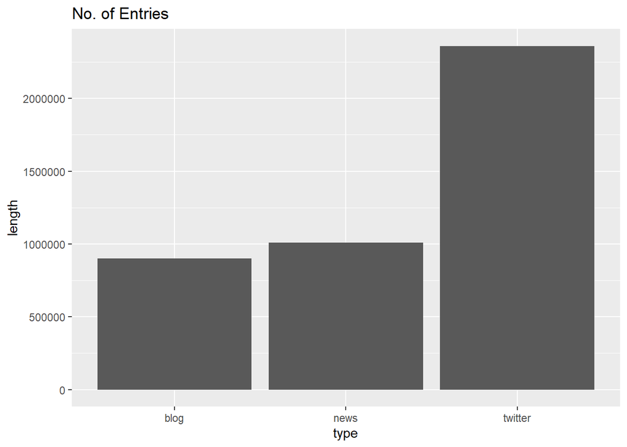

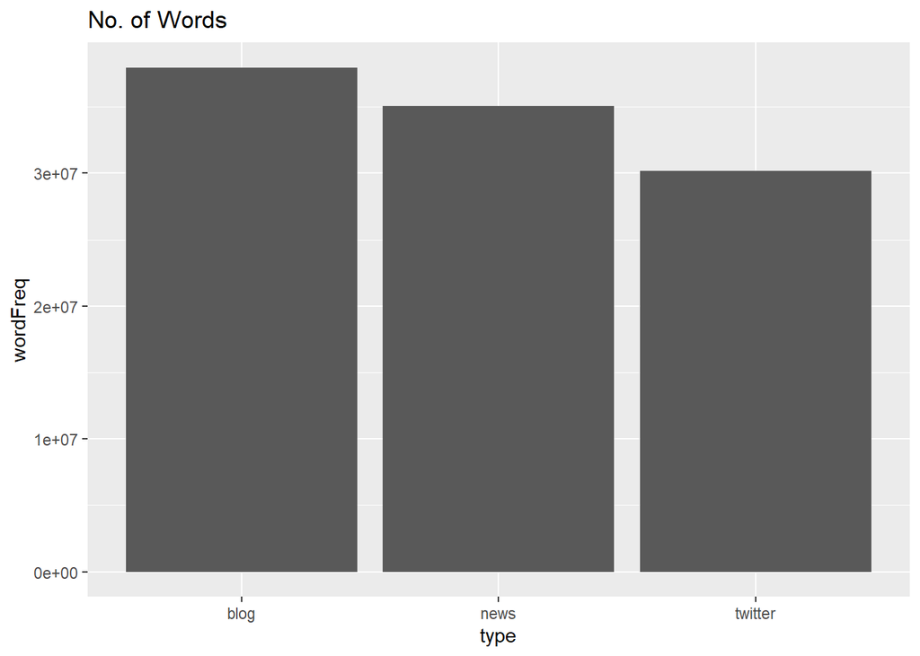

## Data Sampling

From statistical principles we know that we do not have to create a word matrix using every single entry available. As long as we can perform random sampling, we can opt to work with a smaller subset of data to perform our NLP. Here we choose to sample 10% of the data, using a binomial distribution with p = 0.1 to select randomly for us the sample dataset.

```r
dataSample <- list(blog = NA, news = NA, twitter = NA)
dataSampleSummary <- data.frame(type = c("blog", "news", "twitter"))

set.seed(123)
binomial <- function(dataList) {
  rbinom(dataList, 1, .1)
}
dataToSample <- lapply(dataAll, binomial)
for (i in 1:3) {
  dataSample[[i]] <- subset(dataAll[[i]],dataToSample[[i]] == 1)
  dataSample[[i]] <- gsub('[^[:alnum:][:space:]]+','',dataSample[[i]])
}
```

Similarly, we can look at the summary statistics of this smaller dataset.

```
##      type length wordFreq
## 1    blog  89852  3722563
## 2    news 100650  3403007
## 3 twitter 236316  2972892
```

## Word Frequency Exploration

We would now like to explore deeper into each dataset. One of things we are curious about are what are some of the most frequently occuring words? To do this we first create our vector corpus. Once we do so we can choose to remove the data sample variable to save some space.

```r
corpus <- VCorpus(VectorSource(dataSample))
rm(dataSample)
```

Then we define a function that will transform each corpus into a term document matrix, which allows us to easily calculate the word frequencies in each dataset. We use a ggplot to present the results visually.

```r
singleWordExploration <- function(corpus, name) {
  tdm <- TermDocumentMatrix(corpus[name], control = list(wordLengths = c(3,Inf),
                                                         removePunctuation = TRUE,
                                                         stopwords = TRUE))
  freq <- data.frame(word = tdm$dimnames$Terms, frequency = tdm$v)
  freq <- arrange(freq, -frequency)
  freq$word = with(freq, reorder(word, frequency))
  ggplot(freq[1:20,], aes(x = word, y = frequency)) + geom_bar(stat = "identity") + coord_flip() +
    labs(title = paste("Top 25 non-stopwords in", name, "corpus", sep = " "))
}
```

Word frequency analysis:

[figure not shown]

[figure not shown]

[figure not shown]

## Algorithm Design

Moving on from this milestone, our ultimate goal is to create a n-grams of the dataset, so that we can predict, based on popular frequencies, what word would be typed next to an existing string of words.

This involves:

### 1. Filtering the corpus for numbers, punctuations, symbols. (We will however leave in common stop-words)

### 2. Transforming the corpus into an n-gram

### 3. Search and return the n-gram for 2 parts: search n-1 matcher and match n-th trailing word

This means that we can now use the n-1 matcher phrase to match the user’s input, and spit out the n-th trailing word as the prediction!

Let’s look at the tokenizing function:

```r
tokenizing <- function(corpus, name, nOrder) {
  tokenizer <- function(text) {
    unlist(lapply(ngrams(words(text), nOrder), paste, collapse = " "), use.names = FALSE)
  }
  control_list_ngram = list(tokenize = tokenizer)

  corpus <- tm_map(corpus, content_transformer(tolower))
  corpus <- tm_map(corpus, removeNumbers)

  ngram <- TermDocumentMatrix(corpus[name], control = control_list_ngram)
  ngram <- data.frame(word = ngram$dimnames$Terms, frequency = ngram$v)

  return(ngram)
}
```

We can then simply get out n-grams: (code suppressed, code for “twitter” and “blog” not shown)

```r
Nbigram <- tokenizing(corpus, "news", 2)
Ntrigram <- tokenizing(corpus, "news", 3)
Nquadgram <- tokenizing(corpus, "news", 4)
```

We will use bigrams, trigrams and quadgrams appropriately based on how many words are available in the input and use a waterfall approach: if the upper-hierachy n-grams does not manage to produce any predictons, the input is shortened and the lower-hierachy n-gram is used.

A bigram-trigram prediction function will look something like this:

```r
predictor <- function(input, bigram, trigram) {
  returnLastWord <- function(stringText) {
    wordList <- strsplit(as.String(stringText), " ")[[1]]
    wordList[length(wordList)]
  }

  searcher <- function(before, ngram) {
    after <- subset(ngram, str_detect(ngram$word, fixed(paste(before, "", sep = " "))))
    after <- arrange(after, -frequency)[1:3,]
    sapply(after$word, returnLastWord)
  }
  input <- tolower(input)
  inputSplit <- strsplit(as.String(input), " ")[[1]]

  if (length(inputSplit) == 1) {
    result <- searcher(inputSplit[length(inputSplit)], bigram)

  } else {
    result <- searcher(paste(inputSplit[length(inputSplit)-1],
                             inputSplit[length(inputSplit)], sep = " "), trigram)
    if (result[1] == "NA") {
      result <- searcher(inputSplit[length(inputSplit)], bigram)
    }

  }
  result
}
```

For example: if “however this apple” does not match any quadgram entries, we will reduce it to “this apple” and attempt to match it to a trigram entry.

### 4. Design the prediction algorithm that takes in an input and outputs the prediction based on the n-grams

We will thus return the top 3 results of the prediction. Shinyapp hosted as an example execution of the application here: https://angrunhao.shinyapps.io/coursera-data-science-capstone/